# FUTU (富途控股) 기업 분석 보고서

Alpha Hunter Hidden Gem Week 18 — 중국 핀테크 최강 브로커리지, 매출 53% 폭증

Author

Alpha Hunter × Chimera AI

Published

May 1, 2026

# 기업 개요

| 항목 | 내용 |
| --- | --- |
| **종목명** | Futu Holdings Limited (FUTU, NASDAQ / 8585.HK) |
| **업종** | Financial Services / Capital Markets (온라인 브로커리지) |
| **핵심 사업** | 디지털 증권거래 플랫폼 Moomoo, Futubull 운영 |
| **시총** | $21.7B (약 30조원) |
| **현재가** | $154.51 |
| **PER (TTM/Fwd)** | 15.1x / 11.3x |
| **PBR** | 4.2x |
| **ROE** | 33.1% |
| **배당수익률** | 1.2% (특별배당 포함) |
| **컨센서스** | Strong Buy (20명 애널리스트, 평균 타겟 $232) |

**핵심 투자 포인트**

## 0.1 사업 요약

Futu Holdings는 **아시아 최대 디지털 증권거래 플랫폼** 운영사다. 홍콩·미국·싱가포르·일본·호주·말레이시아 등에서 **Moomoo**와 **Futubull** 브랜드로 서비스하며, 주식·옵션·ETF·펀드·채권 거래를 제공한다.

- **브로커리지 수수료** — 전체 매출의 핵심. 거래량 증가에 직접 연동
- **이자수익** — 고객 증거금 및 마진론 이자. 금리 환경에 민감하나 안정적 수익원
- **기업 서비스** — IPO 인수·주주서비스. Tencent, NIO 등 주요 고객
- **자산관리** — Moomoo Financial 통한 자산관리 서비스 확대 중
- **글로벌 확장** — 2026년 기준 12개국 라이선스 보유, 동남아·일본 급성장

## 0.2 왜 히든젬인가?

**5가지 핵심 모트 (경제적 해자)**

1. **네트워크 효과**: 2,200만+ 사용자 기반 → 유동성 집중 → 신규 유입 가속
2. **규모의 경제**: 영업이익률 69%의 초고효율 플랫폼 (직원 3,540명으로 $21.7B 시총)
3. **전환비용**: 포트폴리오·거래이력·소셜기능이 묶여 이탈 어려움
4. **기술적 해자**: 자체 개발 트레이딩 엔진, AI 리서치 툴, 실시간 데이터
5. **규제 장벽**: 12개국 브로커리지 라이선스 = 신규 진입 차단

# 1 실적 분석

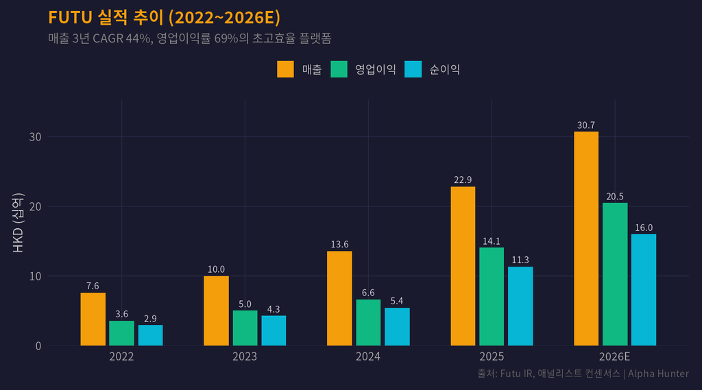

Figure 1: FUTU 매출·영업이익·순이익 추이 (단위: HKD 십억)

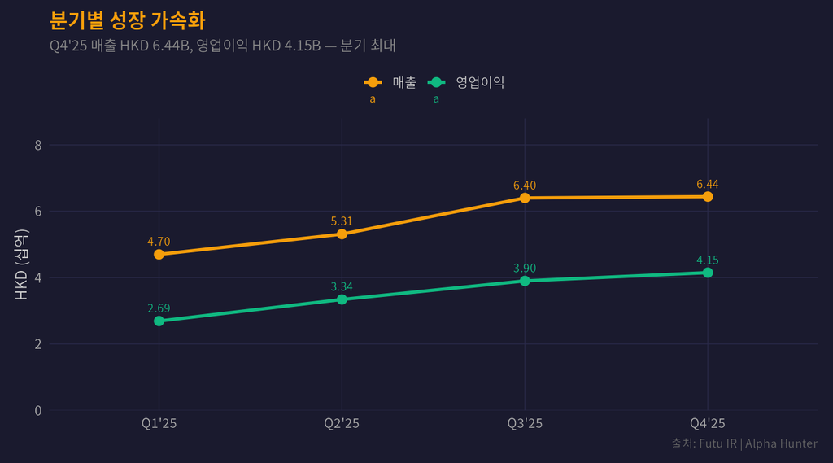

Figure 2: FUTU 분기별 매출·영업이익 추이 (HKD 십억)

# 2 주가 추이 (52주)

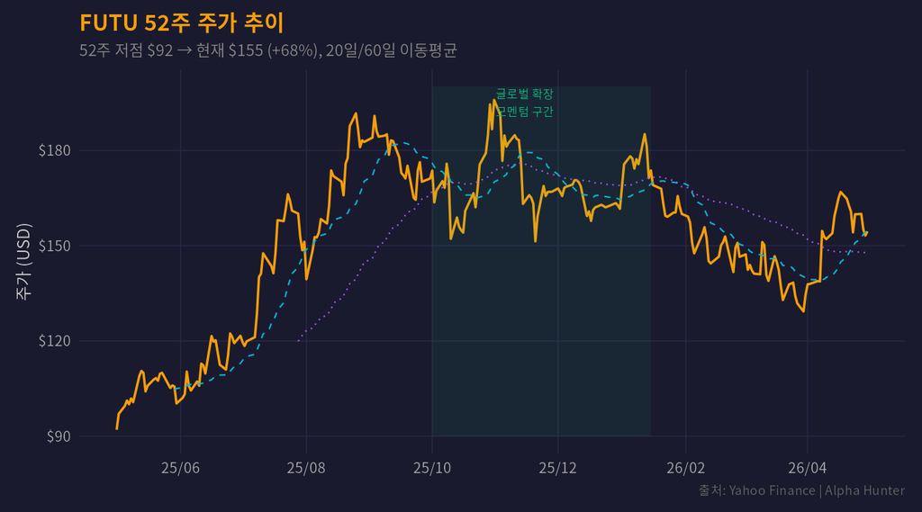

Figure 3: FUTU 52주 주가 추이 ($92 → $155, +68%)

# 3 밸류에이션 비교 (동종업종)

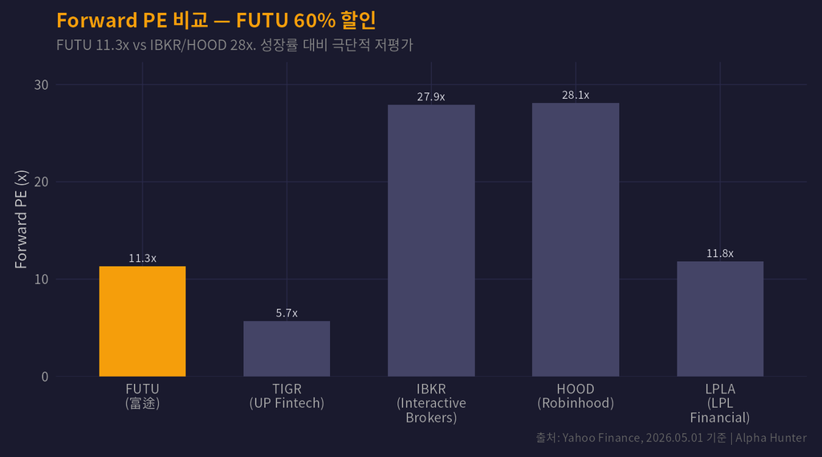

Figure 4: 글로벌 온라인 브로커리지 밸류에이션 비교

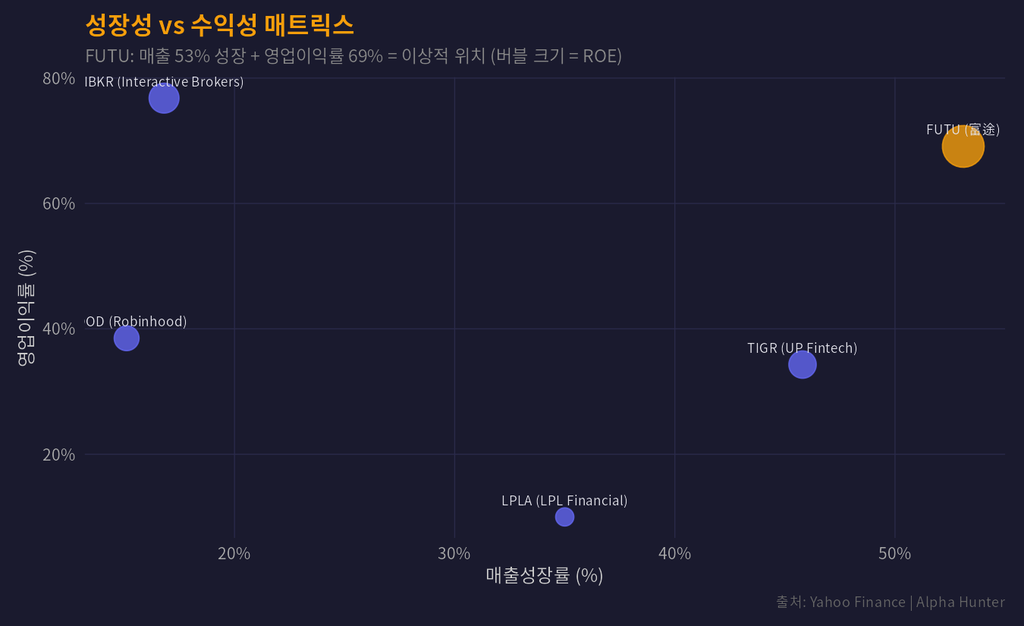

Figure 5: 영업이익률 vs 매출성장률 — FUTU의 압도적 위치

# 4 워런 버핏 해자 레이더 차트

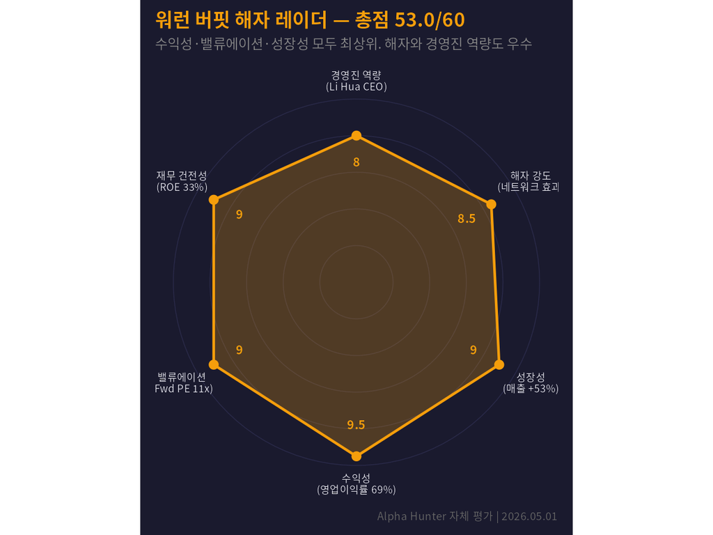

Figure 6: 워런 버핏 경제적 해자 평가 (10점 만점)

# 5 피터 린치 스토리 점수

[figure not shown]

Figure 7: 피터 린치 스토리 분류 — Fast Grower (매출 53% 성장)

# 6 리스크 팩터 대시보드

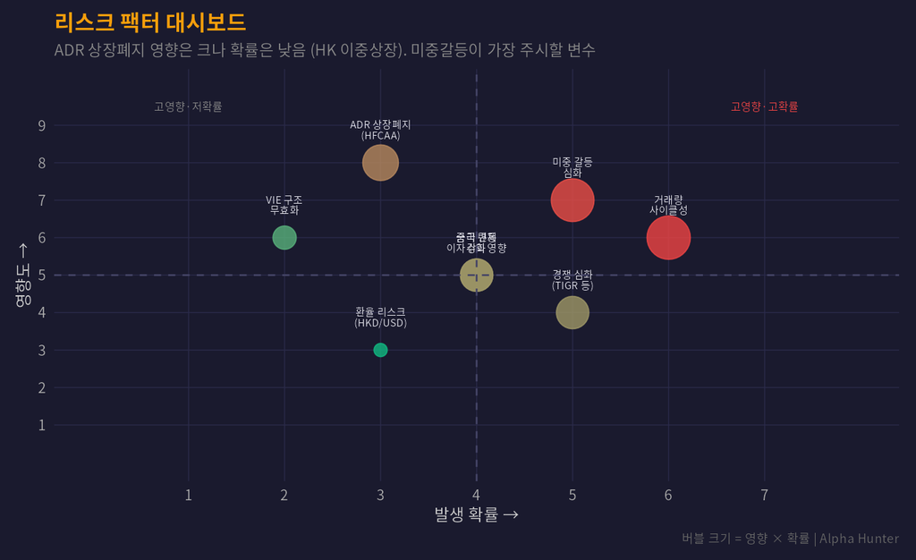

Figure 8: 리스크 팩터 대시보드 — 정치 리스크가 최대 변수

## 6.1 중국 특유 리스크 상세

**VIE 구조 리스크**

FUTU는 **Variable Interest Entity(VIE)** 구조를 사용한다. US 투자자는 중국 본토 운영 법인의 직접 지분이 아닌 케이맨 제도 법인의 지분을 보유한다. 중국 법원이 VIE 계약을 무효화할 경우 자산 접근이 제한될 수 있다. **다만** FUTU는 홍콩 기반이며 홍콩 증권거래소 이중상장(8585.HK)을 완료하여 리스크가 크게 완화되었다.

**ADR 상장폐지 리스크 (HFCAA)**

2025년 “America First Investment Policy” 메모로 중국 ADR 상장폐지 우려가 재부상했다. 286개 중국 기업이 미국에 상장 중이며, 시총 $1.1조 규모다. **FUTU는 홍콩 이중상장으로 상장폐지 시에도 HK 시장 전환이 가능**하다. 실제 ADR 시총의 75%+ 기업이 이미 이중상장을 완료했다.

### 6.1.1 중국 산업 트렌드 연결

| 트렌드 | FUTU 수혜 |
| --- | --- |
| **전기차 (EV)** | NIO, XPeng, Li Auto 등 중국 EV 기업 IPO/거래 → 브로커리지 수수료 |
| **반도체** | SMIC, 화홍반도체 등 중국 반도체 상장 수요 → 기업서비스 매출 |
| **바이오** | BeiGene, Legend Bio 등 홍콩 18A 바이오텍 IPO 활황 |
| **AI/클라우드** | DeepSeek, 바이두 AI 열풍 → 중국 테크주 거래량 폭증 |

# 7 매수/목표/손절 시나리오

[figure not shown]

Figure 9: Bull/Base/Bear 시나리오별 목표가

## 7.1 투자 시나리오 상세

| 시나리오 | 전제 조건 | 목표가 | 기대수익 |
| --- | --- | --- | --- |
| **Bull** | 글로벌 고객 100만+ 신규, 매출 +40% 지속, 미중 관계 안정 | $280 | +81% |
| **Base** | 고객 80만 신규, 매출 +30%, 현 규제 유지 | $200 | +29% |
| **Bear** | 미중 갈등 재심화, ADR 유동성 감소, 거래량 급감 | $120 | -22% |

# 8 결론

**Alpha Hunter 최종 판단: **매수 (BUY)**

FUTU Holdings는 **성장 + 수익성 + 밸류에이션** 삼박자를 갖춘 드문 중국 핀테크다.

- **PEG 0.21x** — 매출 53% 성장에 Fwd PE 11.3x는 극단적 저평가
- **영업이익률 69%** — 글로벌 브로커리지 중 최상위 수준
- **ROE 33%** — 자본 효율성 탁월
- **홍콩 이중상장** — ADR 상장폐지 리스크 선제 대응 완료
- **글로벌 확장** — 동남아·일본·호주 등 12개국 라이선스

**최대 리스크는 미중 지정학적 갈등**이다. 관세전쟁 재격화 시 중국 ADR 전반에 매도 압력이 발생할 수 있으나, FUTU의 펀더멘털 대비 밸류에이션 할인이 충분한 안전마진을 제공한다.

**면책 조항**

이 프로젝트는 가상 투자 시뮬레이션 목적으로 작성되었습니다. 실제 투자 권유가 아닙니다.

*Alpha Hunter × Chimera AI | Week 18 | 2026-05-01*